# Cluster_Analysis Presentation

Jonathan Reeves

March 27, 2015

## Cluster Analysis

### Paper Summary

The paper examines variation in dental micro-wear in neanderthal specimens across broad geographic, temporal, and paleoecological. The study discovers that despite the fact that there is no significant variation dictated by geography and time, there are significant dental micro-wear signatures according to paleoecology. The paper suggests that plant food form an important part of the their and the utilization of plant food increases with tree cover.

### Their Analysis in R.

The analytic methods of this paper are broken into three major chunks. Two of which are relevant to the cluster analysis. Firstly, the employ a MANOVA to look at the significance of their three spatio-temporal groups(i.e geography, Marine isotope stage, and paleoecology). Then secondly they use an ANOVA assess the significance of the micro-wear analysis between groups.The results of these two analysis provided the basis for the data that they include within their third analysis; a cluster analysis. While we will not be focusing on the former two portions of the analysis we will focus the published results so that we can organize our data into a cluster analysis.

#### Reading in.

```r
dem.tals <- read.csv("http://hompal-stats.wabarr.com/datasets/Zaatari_neanderthal.csv", header = TRUE)

head(dem.tals)
```

```
##            region      specimen mis paleovegetation.cover tooth Asfc
## 1 Northern Europe         Spy I   3                  open   RM2 1.37
## 2  Central Europe St. Cesaire 1   3                 mixed   RM1 2.33
## 3  Central Europe Vindija 11.45   3                 mixed   LM2 0.92
## 4  Central Europe Vindija 11.46   3                 mixed   LM1 1.17
## 5  Central Europe  Vindija 12.1   3                 mixed   RM2 1.12
## 6  Central Europe       Ochoz 1  NA                  <NA>   RM1 1.09
##   epLsar   Smc     Tfv HAsfc
## 1 0.0032 0.267  9854.3 0.039
## 2 0.0016 0.208  7687.3 0.435
## 3 0.0026 0.150  2239.4 0.457
## 4 0.0030 2.033 10389.0 0.108
## 5 0.0031 0.267 17865.4 0.256
## 6 0.0037 0.342  5752.1 0.018
```

```r
## We will use the hunter-gather data later

hg.means <- read.csv("http://hompal-stats.wabarr.com/datasets/Zaatari_hunter_gatherer.csv", header = TRUE)
head(hg.means)
```

```
##     sample  Asfc epLsar   Smc    Tfv HAsfc
## 1 fuegians 0.948 0.0044 0.400 5224.8 0.109
## 2  chumash 2.787 0.0023 0.190 6635.9 0.191
## 3 khoe-san 3.548 0.0020 0.176 9272.0 0.325
## 4   tigara 6.569 0.0029 0.213 1191.2 0.267
```

#### Averages and Standard Deviation

Once the authors had separated the specimens into their groups, they calculated the mean and the standard deviation for each of the variables captured by the micro-wear study. So we will have to calculate these for our data below. However, the MANOVA suggested that only the variation observed within the paleoecological groupings was significant so we will only calculate the means for the paleoenvironment grouping. Furthermore, only micro-wear variables that proved to have significantly different means according to the ANOVA, were included in the cluster analysis. So we will only calculate the mean for surface complexity (Asfc) and surface heterogeneity (HAsfc).

```r
library(dplyr)
paleoecological.means <- group_by(dem.tals, paleovegetation.cover)
paleoecological.means <- summarize(.data = paleoecological.means, Asfc = mean(Asfc), HAsfc = mean(HAsfc))

## we will need to remove the row representing the NA values

paleoecological.means <- paleoecological.means[-4,]

paleoecological.means
```

```
## Source: local data frame [3 x 3]
##
##   paleovegetation.cover   Asfc   HAsfc
## 1                 mixed 1.5380 0.25960
## 2                  open 1.0780 0.11200
## 3                wooded 2.7025 0.63175
```

#### Combine the means for each paleoecological division with Neanderthal and Hunter Gatherer data

There study not only compared not only these paleoecological groupings but modern day hunter-gather groups, and neanderthals specimens where the environment is unknown. So we’ll need to do some data wrangling to combined all of these into a single data-fame

```r
## First the non-grouped neanderthal specimeans
sub.dem.tals <- dem.tals[, c("specimen", "Asfc", "HAsfc")]
head(sub.dem.tals)
```

```
##        specimen Asfc HAsfc
## 1         Spy I 1.37 0.039
## 2 St. Cesaire 1 2.33 0.435
## 3 Vindija 11.45 0.92 0.457
## 4 Vindija 11.46 1.17 0.108
## 5  Vindija 12.1 1.12 0.256
## 6       Ochoz 1 1.09 0.018
```

```r
## you can also do this with row names but we don't have any yet.
sub.dem.tals <- sub.dem.tals[c(6, 12 ,19:21,24),]

## now the hunter-gatherers

hg.means.clip <- hg.means[,c(1,2,6)]
```

Lastly we are going to use the rbind function to combined all of these together. Is a nifty way to combined rows from different data frames that are organized the same way. The two things you need to make sure of in order for this to work is that each data.frame has the same number of columns and that the column names are the same. So we will need to change some column names so that the merge goes smoothly.

```r
names(sub.dem.tals)[names(sub.dem.tals)=="specimen"] <- "sample"
names(paleoecological.means)[names(paleoecological.means)=="paleovegetation.cover"] <- "sample"

merge <- rbind(sub.dem.tals, paleoecological.means, hg.means.clip)

merge
```

```
##             sample   Asfc   HAsfc
## 6          Ochoz 1 1.0900 0.01800
## 12    Monsempron 3 3.6100 0.40600
## 19      Guattari 3 0.7000 0.17000
## 20  Saccopastore 1 0.9700 0.78300
## 21  Saccopastore 2 1.1900 0.61300
## 24         Tabun I 2.2500 0.55200
## 7            mixed 1.5380 0.25960
## 8             open 1.0780 0.11200
## 9           wooded 2.7025 0.63175
## 10        fuegians 0.9480 0.10900
## 11         chumash 2.7870 0.19100
## 121       khoe-san 3.5480 0.32500
## 13          tigara 6.5690 0.26700
```

### The Cluster Analysis

Here we will carried out the cluster analysis as it was in the article. Specifically the paper uses a hierarchical cluster analysis with complete linkages and euclidean distance. This following will go through each of the steps of preparing the data and carrying out the analysis as well as displaying the results

#### Make row names

Because we are going to have to convert our data-frame into a matrix we are going to have to get rid of any variable that isn’t a numeric. However, we still want to keep the information associated with the appropriate specimen. So we are going to turn the first column of sample names into row names. This will also be important when we display our dendrogram.

```r
## Adding row names
rownames(merge) <- merge[,1]
## create matrix
merge.matrix <- as.matrix(merge[,-1])
merge.matrix
```

```
##                  Asfc   HAsfc
## Ochoz 1        1.0900 0.01800
## Monsempron 3   3.6100 0.40600
## Guattari 3     0.7000 0.17000
## Saccopastore 1 0.9700 0.78300
## Saccopastore 2 1.1900 0.61300
## Tabun I        2.2500 0.55200
## mixed          1.5380 0.25960
## open           1.0780 0.11200
## wooded         2.7025 0.63175
## fuegians       0.9480 0.10900
## chumash        2.7870 0.19100
## khoe-san       3.5480 0.32500
## tigara         6.5690 0.26700
```

#### Standardizing data

Due to size differences the authors use a z-score to standardize their values. Now that our data is in matrix we can use the scale function to standardize our values.

```r
scaled <- scale(x = merge.matrix)
scaled
```

```
##                       Asfc       HAsfc
## Ochoz 1        -0.68950095 -1.36096054
## Monsempron 3    0.83563670  0.27218563
## Guattari 3     -0.92553416 -0.72117132
## Saccopastore 1 -0.76212655  1.85903127
## Saccopastore 2 -0.62897961  1.14347753
## Tabun I         0.01254654  0.88672002
## mixed          -0.41836537 -0.34403241
## open           -0.69676351 -0.96530141
## wooded          0.28640558  1.22239890
## fuegians       -0.77544124 -0.97792883
## chumash         0.33754611 -0.63277938
## khoe-san        0.79811347 -0.06875468
## tigara          2.62646300 -0.31288477
## attr(,"scaled:center")
##      Asfc     HAsfc
## 2.2292692 0.3413346
## attr(,"scaled:scale")
##      Asfc     HAsfc
## 1.6523099 0.2375782
```

#### Calculate distances

In order to do a cluster analysis you need to calculate the distance between all of your specimens using the dist function

```r
### Make sure that method = "euclidean".

distances <- dist(scaled, method = "euclidian")
```

#### Cluster Analysis

Use the hclust function carry our your hierarchical cluster analysis. You can choose what type of linkages you would your cluster analysis to use by using the method argument. In the case of the paper we want to use “complete” for complete linkages.

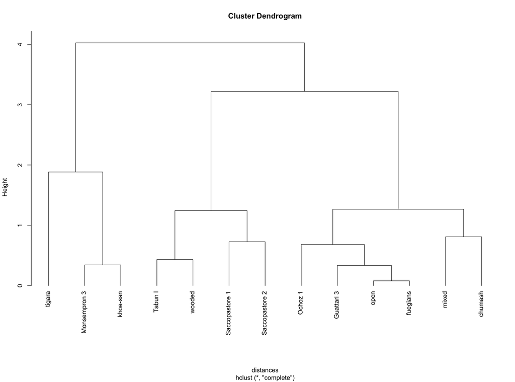

```r
cluster <- hclust(d = distances, method = "complete")

## once you've done that, you can then plot your cluster analysis a dendrogram
plot(cluster, hang = -1)
```

#### Because we all love and use GGplot

Believe it or not, you cannot plot dendrograms using the ggplot package. However, you can download ggdendro which allows you to do so and customize your dendrogram as you like!

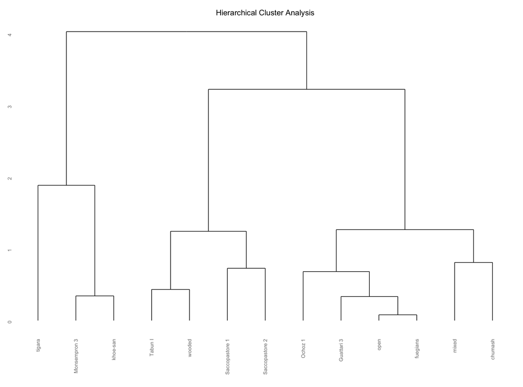

```r
library(ggplot2)
# install package if you don't have it.
library(ggdendro)

ggdendrogram(cluster, labels = TRUE) + labs(title = "Hierarchical Cluster Analysis", y = "Euclidean Distance")
```

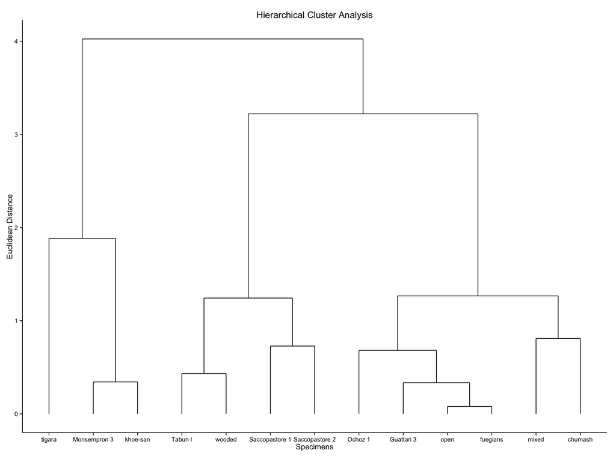

```r
### Add themes

ggdendrogram(cluster, labels = TRUE) + labs(title = "Hierarchical Cluster Analysis", y = "Euclidean Distance", x = "Specimens") + theme_classic()
```

See http://cran.r-project.org/web/packages/ggdendro/vignettes/ggdendro.html for all of the possibilities for your dendrograms